# What is physics informed ML

Go over a tutorial on physics informed ML looking at 1D harmonic equation

Author

Nicholas Harbour

Published

November 21, 2024, 12:36:27

Modified

November 21, 2024, 12:35:38

# 1 1D harmonic oscillator physics-informed neural network (PINN)

We are follwoing this tutorial with code here: https://github.com/benmoseley/harmonic-oscillator-pinn/blob/main/Harmonic%20oscillator%20PINN.ipynb based on this blog post https://benmoseley.blog/my-research/so-what-is-a-physics-informed-neural-network/

## 1.1 Problem overview

The example problem we solve here is the 1D damped harmonic oscillator:

$$m \frac{d^2x}{dt^2} + \mu \frac{dx}{dt} + kx = 0$$

With initial conditions

$$x(0) = 1, \; \; \frac{dx}{dt} = 0$$

We will focus on solving the problem under dmpened state

$$\delta < w_0 \; \text{with} \; \delta = \frac{\mu}{2m}, \; w_0 = \sqrt{\frac{k}{m}}$$

This has the follwoing analytical solution

$$x(t) = e^{-\delta t}(2A cos(\phi + wt))$$

with $w = \sqrt{w_0^2 - \delta^2}$

For more info on the damped harmonic oscilator see this blog post: https://beltoforion.de/en/harmonic_oscillator/

## 1.2 Workflow overview

- First we will train a standard neural network to interpolate a small part of the solution, using some observed training points from the solution.
- Next, we will train a PINN to extrapolate the full solution outside of these training points by penalising the underlying differential equation in its loss function.

## 1.3 Import modules and define functions

```python
import numpy as np
import torch
import torch.nn as nn
import matplotlib.pyplot as plt
from PIL import Image
```

```python
def save_gif_PIL(outfile, files, fps=5, loop=0):
    "Helper function for saving GIFs"
    imgs = [Image.open(file) for file in files]
    imgs[0].save(fp=outfile, format='GIF', append_images=imgs[1:], save_all=True, duration=int(1000/fps), loop=loop)



def oscillator(d, w0, x):
    """
    Defines the analytical solution to the 1D underdamped harmonic oscillator problem.
    Equations taken from: https://beltoforion.de/en/harmonic_oscillator/
    """
    assert d < w0
    w = np.sqrt(w0**2-d**2)
    phi = np.arctan(-d/w)
    A = 1/(2*np.cos(phi))
    cos = torch.cos(phi+w*x)
    sin = torch.sin(phi+w*x)
    exp = torch.exp(-d*x)
    y  = exp*2*A*cos
    return y

class FCN(nn.Module):
    """
    Defines a connected network
    """

    def __init__(self, N_INPUT, N_OUTPUT, N_HIDDEN, N_LAYERS):
        super().__init__()
        activation = nn.Tanh
        self.fcs = nn.Sequential(*[
                        nn.Linear(N_INPUT, N_HIDDEN),
                        activation()])
        self.fch = nn.Sequential(*[
                        nn.Sequential(*[
                            nn.Linear(N_HIDDEN, N_HIDDEN),
                            activation()]) for _ in range(N_LAYERS-1)])
        self.fce = nn.Linear(N_HIDDEN, N_OUTPUT)

    def forward(self, x):
        x = self.fcs(x)
        x = self.fch(x)
        x = self.fce(x)
        return x
```

## 1.4 generate training data

First, we generate some training data from a small part of the true analytical solution.

For this problem, we use, $\delta = 2$, $w_0 = 20$ and try to learn the solution over the domain $x \in [0,1]$.

```
torch.Size([10, 1]) torch.Size([10, 1])
```

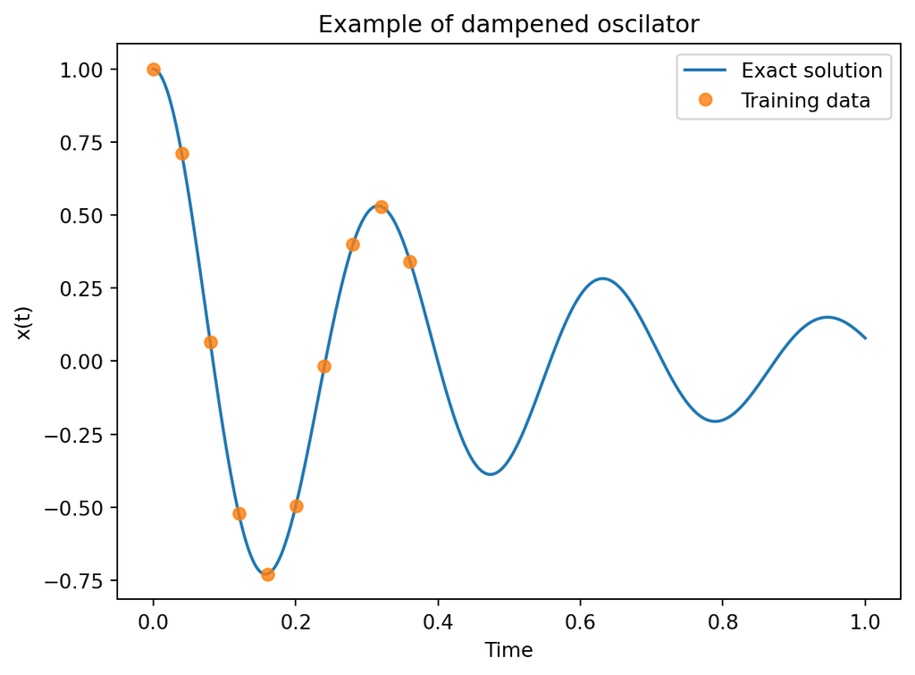

```python
d, w0 = 2, 20

# get the analytical solution over the full domain
x = torch.linspace(0,1,500).view(-1,1)
y = oscillator(d, w0, x).view(-1,1)
#print(x.shape, y.shape)

# slice out a small number of points from the LHS of the domain
x_data = x[0:200:20]
y_data = y[0:200:20]
print(x_data.shape, y_data.shape)

plt.figure()
plt.plot(x, y, label="Exact solution")
plt.plot(x_data, y_data,'o', color="tab:orange", label="Training data", alpha = 0.8)
plt.xlabel("Time")
plt.ylabel("x(t)")
plt.title("Example of dampened oscilator")
plt.legend()
plt.show()
```

## 1.5 Normal neural network

Next, we train a standard neural network (fully connected network) to fit these training points.

We find that the network is able to fit the solution very closely in the vicinity of the training points, but does not learn an accurate solution outside of them.

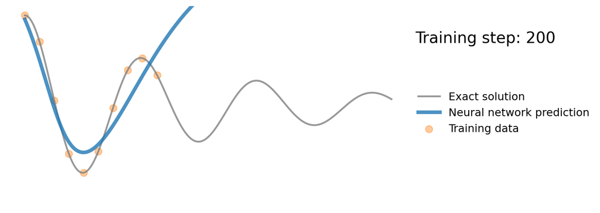

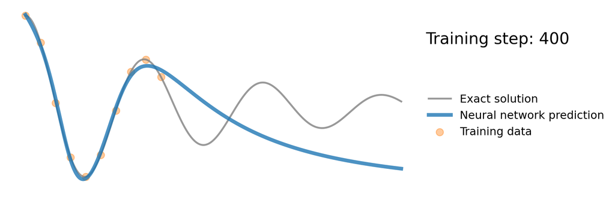

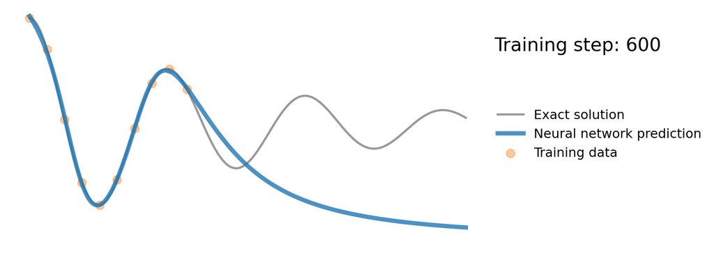

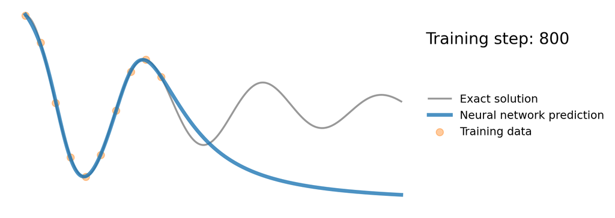

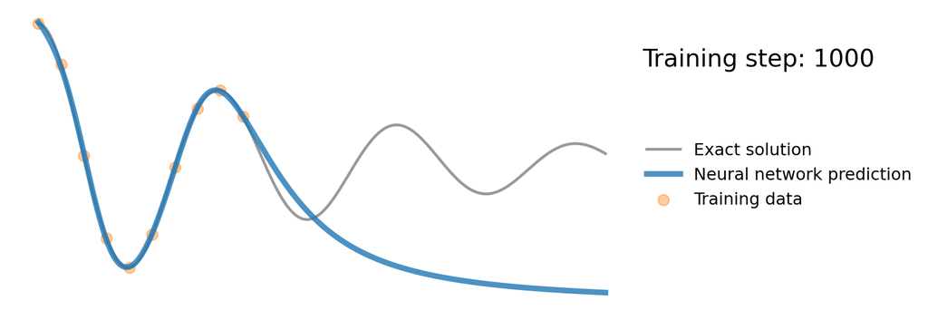

```python
def plot_result(x,y,x_data,y_data,yh,xp=None):
    "Pretty plot training results"
    plt.figure(figsize=(8,4))
    plt.plot(x,y, color="grey", linewidth=2, alpha=0.8, label="Exact solution")
    plt.plot(x,yh, color="tab:blue", linewidth=4, alpha=0.8, label="Neural network prediction")
    plt.scatter(x_data, y_data, s=60, color="tab:orange", alpha=0.4, label='Training data')
    if xp is not None:
        plt.scatter(xp, -0*torch.ones_like(xp), s=60, color="tab:green", alpha=0.4,
                    label='Physics loss training locations')
    l = plt.legend(loc=(1.01,0.34), frameon=False, fontsize="large")
    plt.setp(l.get_texts(), color="k")
    plt.xlim(-0.05, 1.05)
    plt.ylim(-1.1, 1.1)
    plt.text(1.065,0.7,"Training step: %i"%(i+1),fontsize="xx-large",color="k")
    plt.axis("off")


# train standard neural network to fit training data
torch.manual_seed(123)
model = FCN(1,1,32,3)
optimizer = torch.optim.Adam(model.parameters(),lr=1e-3)
files = []
save_loss =  []
for i in range(1000):
    optimizer.zero_grad()
    yh = model(x_data)
    # use mean squared error
    loss = torch.mean((yh-y_data)**2)
    save_loss.append(loss.item())
    loss.backward()
    optimizer.step()


    # plot the result as training progresses
    if (i+1) % 5 == 0:

        yh = model(x).detach()

        plot_result(x,y,x_data,y_data,yh)

        file = "plots/nn_%.8i.png"%(i+1)
        plt.savefig(file, bbox_inches='tight', pad_inches=0.1, dpi=100, facecolor="white")
        files.append(file)

        if (i+1) % 200 == 0:
            plt.show()
        else: plt.close("all")

save_gif_PIL("nn.gif", files, fps=20, loop=0)
```

Plot the loss

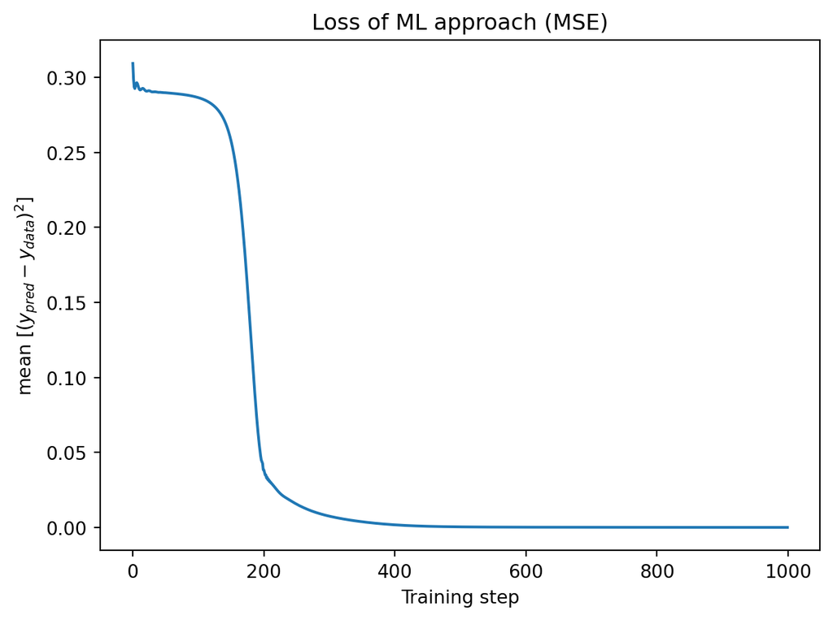

```python
plt.plot(save_loss)
plt.xlabel("Training step")
plt.ylabel("mean [$(y_{pred} - y_{data})^2]$")
plt.title("Loss of ML approach (MSE)")
```

## 1.6 PINN

Finally, we add the underlying differential equation (“physics loss”) to the loss function.

The physics loss aims to ensure that the learned solution is consistent with the underlying differential equation. This is done by penalising the residual of the differential equation over a set of locations sampled from the domain.

Here we evaluate the physics loss at 30 points uniformly spaced over the problem domain $x \in [0,1]$. We can calculate the derivatives of the network solution with respect to its input variable at these points using pytorch’s autodifferentiation features, and can then easily compute the residual of the differential equation using these quantities.

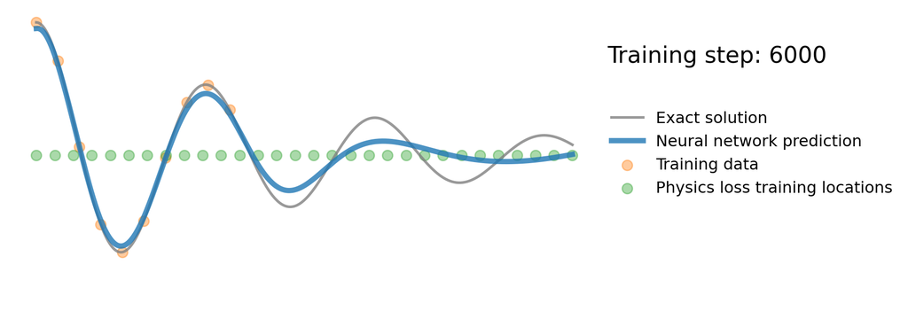

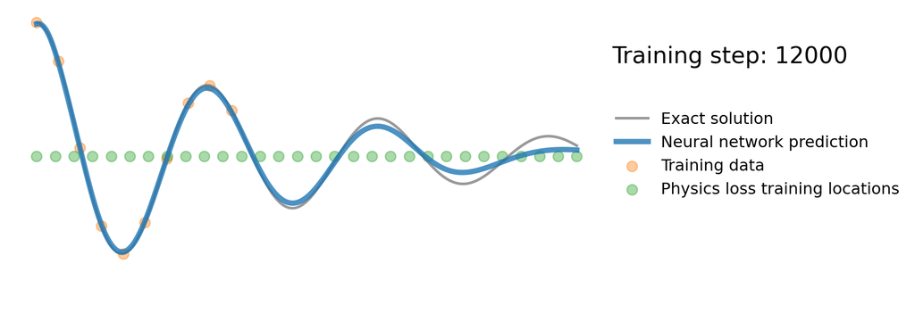

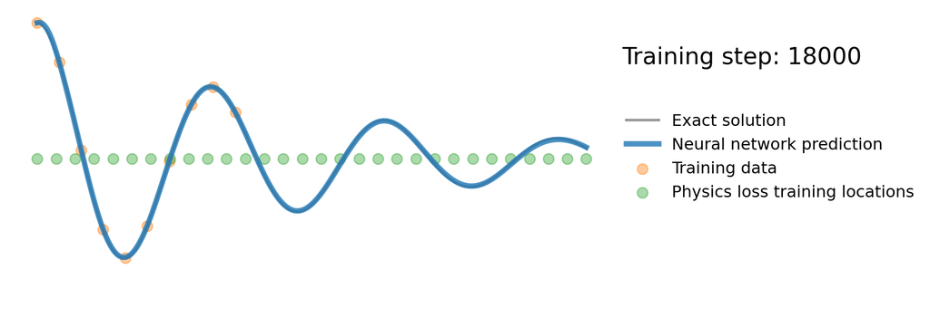

```python
x_physics = torch.linspace(0,1,30).view(-1,1).requires_grad_(True)# sample locations over the problem domain
mu, k = 2*d, w0**2

torch.manual_seed(123)
model = FCN(1,1,32,3)
optimizer = torch.optim.Adam(model.parameters(),lr=1e-4)
files = []
for i in range(20000):
    optimizer.zero_grad()

    # compute the "data loss" same as previously (mean squared error between predicted and observed data points)
    yh = model(x_data)
    loss1 = torch.mean((yh-y_data)**2)

    # compute the "physics loss"
    yhp = model(x_physics)
    dx  = torch.autograd.grad(yhp, x_physics, torch.ones_like(yhp), create_graph=True)[0]# computes dy/dx
    dx2 = torch.autograd.grad(dx,  x_physics, torch.ones_like(dx),  create_graph=True)[0]# computes d^2y/dx^2
    # computes the residual of the 1D harmonic oscillator differential equation. If the equation us staisfied at from the model predictions (as it should be) then this equation should be zero hence the residual is 0
    physics = dx2 + mu*dx + k*yhp
    # Mean squared error of the residual calcualted at all the physics points
    loss2 = (1e-4)*torch.mean(physics**2)

    # add two loss terms together
    loss = loss1 + loss2
    # backpropagate joint loss
    loss.backward()
    optimizer.step()


    # plot the result as training progresses
    if (i+1) % 150 == 0:

        yh = model(x).detach()
        xp = x_physics.detach()

        plot_result(x,y,x_data,y_data,yh,xp)

        file = "plots/pinn_%.8i.png"%(i+1)
        plt.savefig(file, bbox_inches='tight', pad_inches=0.1, dpi=100, facecolor="white")
        files.append(file)

        if (i+1) % 6000 == 0: plt.show()
        else: plt.close("all")

save_gif_PIL("pinn.gif", files, fps=20, loop=0)
```